# TSA Screening Risk Analysis & Incident Rate Assessment

SAKINA SARFRAZ

December 14, 2025

## Project Context

This analysis was originally completed as a final exam project for DATA 2100 (Introduction to Data Analytics) at the University of Pennsylvania. The project has been adapted and expanded with a security analytics framework to demonstrate skills applicable to threat detection and security operations.

**Original Assignment:** Analyze TSA checkpoint and firearm confiscation data to identify patterns and insights.

**Security-Focused Extension:** Reframed analysis to focus on anomaly detection, risk assessment, and threat pattern identification - core skills for Security Operations Center (SOC) analysts.

## Analysis Questions

The following analysis answers specific investigative questions using 2.7M+ TSA checkpoint records from 2022.

## Question #A TSA Checkin & Firearm Confiscations

## Question #1

1. Load in the TSA checkpoint data from Jan 2 through Jan 8 (tsa_2022-01-02_2022-01-08). How many people went through the Terminal B checkpoint at the Philadelphia International Airport (PHL) at 8 AM on January 5, 2022?

```r
unzip("tsa.zip")

tsa <- read.csv("tsa/tsa_2022-01-02_2022-01-08.csv")

#names(tsa)

#unique(tsa$airport)
#unique(tsa$checkpoint_name)
#unique(tsa$date)
#unique(tsa$hour)
#unique(tsa$checkpoint_name[tsa$airport == "Philadelphia International"])


result <- tsa[tsa$airport == "Philadelphia International" &
  tsa$checkpoint_name == "Checkpoint B" &
  tsa$date == "2022-01-05" &
  tsa$hour == "08:00", ]

result$checkins
```

```
## [1] "486"
```

486 people went through the Terminal B checkpoint at the Philadelphia International Airport (PHL) at 8 AM on January 5, 2022.

## Question #2

2. Write a loop that loads in all of the TSA checkpoint data from 2022 and creates on single dataset. Report out dimensions of this new dataset.

```r
unzip("tsa.zip", exdir = "tsa")

files <- list.files("tsa", pattern = "\\.csv$", full.names = TRUE)


tsa_2022 <- data.frame()


for (file in files) {
  temp <- read.csv(file, stringsAsFactors = FALSE)
  tsa_2022 <- rbind(tsa_2022, temp)
}


dim(tsa_2022)
```

```
## [1] 2708662      12
```

The dimensions of this new dataset has 2,708,662 observations and 12 variables.

## Question #3

3. Subset the checkpoint data to include only Philadelphia International (PHL). Aggregate this data to determine the number of people who went through each Philly checkpoint daily.

```r
phl_data <- tsa_2022[tsa_2022$airport == "Philadelphia International", ]


phl_data$checkins <- as.numeric(phl_data$checkins)
phl_daily <- aggregate(checkins ~ checkpoint_name + date, data = phl_data, sum)


head(phl_daily)
```

```
##   checkpoint_name       date checkins
## 1          A East 2022-01-02     2929
## 2    A West Sec 7 2022-01-02     2980
## 3    Checkpoint B 2022-01-02     5993
## 4    Checkpoint C 2022-01-02     1274
## 5 Checkpoint D\\E 2022-01-02     7997
## 6    Checkpoint F 2022-01-02     1752
```

## Question #4

4. Graph the amount of people traveling through each Philly checkpoint every day in 2022. Describe what you learned from your graph.

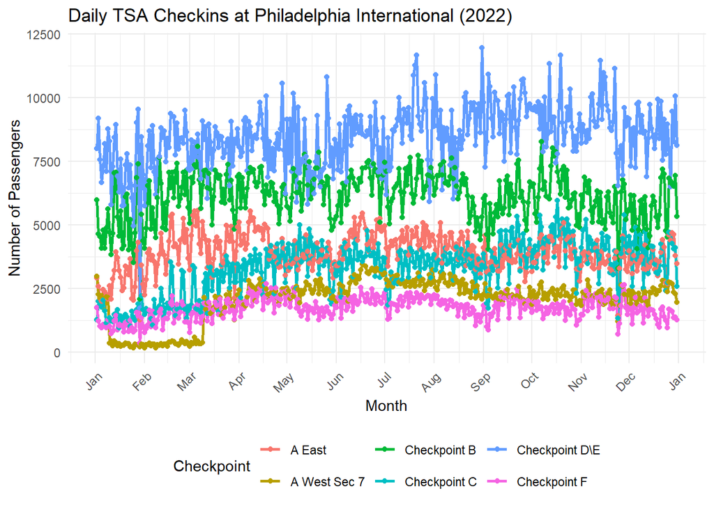

```r
phl_daily$date <- as.Date(phl_daily$date)


ggplot(phl_daily, aes(x = date, y = checkins, color = checkpoint_name)) +
  geom_line(size = 1) +
  geom_point(size = 1.5) +
  labs(title = "Daily TSA Checkins at Philadelphia International (2022)",
    x = "Month",
    y = "Number of Passengers",
    color = "Checkpoint") +
  scale_x_date(date_breaks = "1 month",
    date_labels = "%b") +
  theme_minimal() +
  theme(axis.text.x = element_text(angle = 45, hjust = 1),
    legend.position = "bottom")
```

## Question #5

5. To help assist us with booking flights in the future, we want to create a function that identifies the time of day when an airport is on average the busiest. The goal is to create a single function where you can plug in an airports call letters and the output is the time of day when it is the busiest. Use your newly created function to report out the busiest time to checkin at the New York City area airports: Newark (EWR), John F Kennedy (JFK) and LaGuardia (LGA).

```r
tsa_2022$checkins <- as.numeric(tsa_2022$checkins)
busiest_hour <- function(airport_code) {

  airport_data <- tsa_2022[tsa_2022$call_letters == airport_code, ]


  avg_by_hour <- aggregate(checkins ~ hour, data = airport_data, FUN = mean)


  busiest <- avg_by_hour[which.max(avg_by_hour$checkins), "hour"]

  return(busiest)
}

busiest_hour("EWR")  # Newark
```

```
## [1] "16:00"
```

```r
busiest_hour("JFK")  # John F Kennedy
```

```
## [1] "17:00"
```

```r
busiest_hour("LGA")  # LaGuardia
```

```
## [1] "09:00"
```

The busiest times to check in at the New York City area airports are: Newark (EWR): 16:00 or 4:00 p.m John F Kennedy (JFK): 17:00 or 5:00 p.m LaGuardia (LGA): 09:00 or 9:00 a.m

## Question #6

6. Load in the firearm confiscation data. Which airport confiscated the most firearms in 2022? How many did they confiscate?

```r
tsa_guns_2022 <- read.csv("tsa_guns_2022.csv", stringsAsFactors = FALSE)

#names(tsa_guns_2022)



total_firearms <- aggregate(date ~ airport, data = tsa_guns_2022, FUN = length)
names(total_firearms)[2] <- "num_firearms"

max_idx <- which.max(total_firearms$num_firearms)
busiest_airport <- total_firearms$airport[max_idx]
num_confiscated <- total_firearms$num_firearms[max_idx]


busiest_airport
```

```
## [1] "ATL"
```

```r
num_confiscated
```

```
## [1] 448
```

Hartsfield–Jackson Atlanta International Airport (ATL) confiscated the most firearms in 2022, with 448 total confiscations.

## Question #7

7. Let’s check which airport has the most guns confiscated relative to the number of people who actually go through the check points. To do this, aggregate both the TSA checkin data and the firearm data to get an annual measurement by airport. Merge the datasets together. If there were no confiscations at an airport, make sure this is recorded as a zero. Create a new confiscation rate variable. Out of the airports that confiscated more than 10 guns, which airport had the highest confiscation rate?

```r
tsa_annual <- aggregate(checkins ~ call_letters,
  data = tsa_2022,sum)

names(tsa_annual) <- c("airport", "checkins")


guns_annual <- aggregate(date ~ airport,
  data = tsa_guns_2022,
  FUN = length)

names(guns_annual) <- c("airport", "firearms")


combined <- merge(tsa_annual,
  guns_annual,
  by = "airport",
  all.x = TRUE)

combined$firearms[is.na(combined$firearms)] <- 0

combined$confiscation_rate <- combined$firearms / combined$checkins

over_10 <- combined[combined$firearms > 10, ]

highest_rate_airport <- over_10[
  which.max(over_10$confiscation_rate),
]

highest_rate_airport
```

```
##     airport checkins firearms confiscation_rate
## 250     MCO  2205175      162      7.346356e-05
```

## Question #8

8. Create a graph that plots the number of confiscations by the number of travelers for the airports that confiscated more than 10 guns in 2022. Which airports standout?

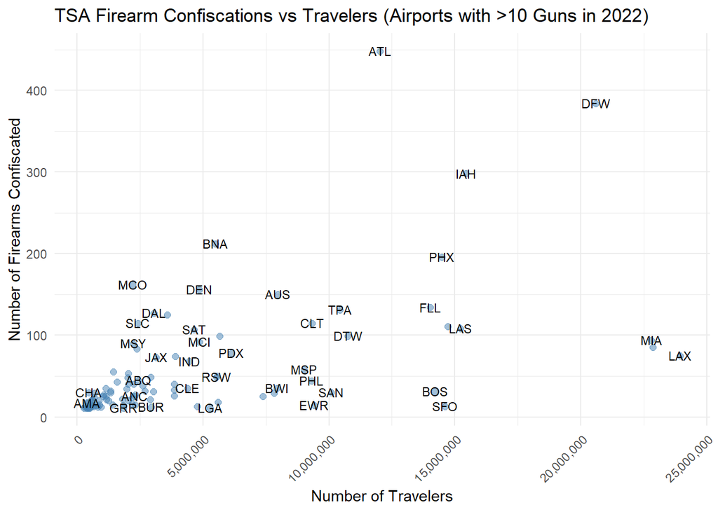

```r
over_10 <- combined[combined$firearms > 10, ]


ggplot(over_10, aes(x = checkins, y = firearms, label = airport)) +
  geom_point(color = "steelblue", size = 2, alpha = 0.5) +
  geom_text(nudge_y = 0.5, size = 3, check_overlap = TRUE) +
  scale_x_continuous(labels = scales::comma) +
  scale_y_continuous(labels = scales::comma) +
  labs(title = "TSA Firearm Confiscations vs Travelers (Airports with >10 Guns in 2022)",
    x = "Number of Travelers",
    y = "Number of Firearms Confiscated") +
  theme_minimal() +
  theme(axis.text.x = element_text(angle = 45, hjust = 1),
    axis.text.y = element_text(angle = 0))
```

```r
ggsave("visualizations/checkpoint_traffic.png",
       plot = last_plot(),
       width = 10,
       height = 6,
       dpi = 300,
       create.dir = TRUE)

ggsave("visualizations/firearm_confiscations.png",
       plot = last_plot(),
       width = 10,
       height = 6,
       dpi = 300,
       create.dir = TRUE)

#combined[combined$airport == "ATL", ]
```

## Appendix: All code used to make this document

```r
knitr::opts_chunk$set(echo = TRUE)
library(tidyverse)
library(dplyr)
library(stringr)
library(maps)
library(lubridate)
library(dslabs)
library(tidyr)
library(readxl)
library(haven)
library(weights)
library(scales)


unzip("tsa.zip")

tsa <- read.csv("tsa/tsa_2022-01-02_2022-01-08.csv")

#names(tsa)

#unique(tsa$airport)
#unique(tsa$checkpoint_name)
#unique(tsa$date)
#unique(tsa$hour)
#unique(tsa$checkpoint_name[tsa$airport == "Philadelphia International"])


result <- tsa[tsa$airport == "Philadelphia International" &
  tsa$checkpoint_name == "Checkpoint B" &
  tsa$date == "2022-01-05" &
  tsa$hour == "08:00", ]

result$checkins





unzip("tsa.zip", exdir = "tsa")

files <- list.files("tsa", pattern = "\\.csv$", full.names = TRUE)


tsa_2022 <- data.frame()


for (file in files) {
  temp <- read.csv(file, stringsAsFactors = FALSE)
  tsa_2022 <- rbind(tsa_2022, temp)
}


dim(tsa_2022)




phl_data <- tsa_2022[tsa_2022$airport == "Philadelphia International", ]


phl_data$checkins <- as.numeric(phl_data$checkins)


phl_daily <- aggregate(checkins ~ checkpoint_name + date, data = phl_data, sum)


head(phl_daily)





phl_daily$date <- as.Date(phl_daily$date)


ggplot(phl_daily, aes(x = date, y = checkins, color = checkpoint_name)) +
  geom_line(size = 1) +
  geom_point(size = 1.5) +
  labs(title = "Daily TSA Checkins at Philadelphia International (2022)",
    x = "Month",
    y = "Number of Passengers",
    color = "Checkpoint") +
  scale_x_date(date_breaks = "1 month",
    date_labels = "%b") +
  theme_minimal() +
  theme(axis.text.x = element_text(angle = 45, hjust = 1),
    legend.position = "bottom")


tsa_2022$checkins <- as.numeric(tsa_2022$checkins)


busiest_hour <- function(airport_code) {

  airport_data <- tsa_2022[tsa_2022$call_letters == airport_code, ]


  avg_by_hour <- aggregate(checkins ~ hour, data = airport_data, FUN = mean)


  busiest <- avg_by_hour[which.max(avg_by_hour$checkins), "hour"]

  return(busiest)
}

busiest_hour("EWR")  # Newark
busiest_hour("JFK")  # John F Kennedy
busiest_hour("LGA")  # LaGuardia






tsa_guns_2022 <- read.csv("tsa_guns_2022.csv", stringsAsFactors = FALSE)

#names(tsa_guns_2022)



total_firearms <- aggregate(date ~ airport, data = tsa_guns_2022, FUN = length)
names(total_firearms)[2] <- "num_firearms"

max_idx <- which.max(total_firearms$num_firearms)
busiest_airport <- total_firearms$airport[max_idx]
num_confiscated <- total_firearms$num_firearms[max_idx]


busiest_airport
num_confiscated





tsa_annual <- aggregate(checkins ~ call_letters,
  data = tsa_2022,sum)

names(tsa_annual) <- c("airport", "checkins")


guns_annual <- aggregate(date ~ airport,
  data = tsa_guns_2022,
  FUN = length)

names(guns_annual) <- c("airport", "firearms")


combined <- merge(tsa_annual,
  guns_annual,
  by = "airport",
  all.x = TRUE)

combined$firearms[is.na(combined$firearms)] <- 0

combined$confiscation_rate <- combined$firearms / combined$checkins

over_10 <- combined[combined$firearms > 10, ]

highest_rate_airport <- over_10[
  which.max(over_10$confiscation_rate),
]

highest_rate_airport



over_10 <- combined[combined$firearms > 10, ]


ggplot(over_10, aes(x = checkins, y = firearms, label = airport)) +
  geom_point(color = "steelblue", size = 2, alpha = 0.5) +
  geom_text(nudge_y = 0.5, size = 3, check_overlap = TRUE) +
  scale_x_continuous(labels = scales::comma) +
  scale_y_continuous(labels = scales::comma) +
  labs(title = "TSA Firearm Confiscations vs Travelers (Airports with >10 Guns in 2022)",
    x = "Number of Travelers",
    y = "Number of Firearms Confiscated") +
  theme_minimal() +
  theme(axis.text.x = element_text(angle = 45, hjust = 1),
    axis.text.y = element_text(angle = 0))



ggsave("visualizations/checkpoint_traffic.png",
       plot = last_plot(),
       width = 10,
       height = 6,
       dpi = 300,
       create.dir = TRUE)

ggsave("visualizations/firearm_confiscations.png",
       plot = last_plot(),
       width = 10,
       height = 6,
       dpi = 300,
       create.dir = TRUE)

#combined[combined$airport == "ATL", ]
```